# ch8_exam_summary

doellomdoel

2024-06-10

## 0. 데이터 로드 powercell

```r
powercell<-read.table("https://users.stat.ufl.edu/~rrandles/sta4210/Rclassnotes/data/textdatasets/KutnerData/Chapter%20%208%20Data%20Sets/CH08TA01.txt")

names(powercell)<-c("Y","X1","X2")

# 정규화된 데이터를 새로운 열에 저장
powercell$x1<-(powercell$X1-1)/0.4
powercell$x2<-(powercell$X2-20)/10

powercell
```

```
##      Y  X1 X2 x1 x2
## 1  150 0.6 10 -1 -1
## 2   86 1.0 10  0 -1
## 3   49 1.4 10  1 -1
## 4  288 0.6 20 -1  0
## 5  157 1.0 20  0  0
## 6  131 1.0 20  0  0
## 7  184 1.0 20  0  0
## 8  109 1.4 20  1  0
## 9  279 0.6 30 -1  1
## 10 235 1.0 30  0  1
## 11 224 1.4 30  1  1
```

```r
# 차원
dim(powercell)
```

```
## [1] 11  5
```

```r
# 요약
summary(powercell)
```

```
##        Y               X1            X2           x1             x2
##  Min.   : 49.0   Min.   :0.6   Min.   :10   Min.   :-1.0   Min.   :-1.0
##  1st Qu.:120.0   1st Qu.:0.8   1st Qu.:15   1st Qu.:-0.5   1st Qu.:-0.5
##  Median :157.0   Median :1.0   Median :20   Median : 0.0   Median : 0.0
##  Mean   :172.0   Mean   :1.0   Mean   :20   Mean   : 0.0   Mean   : 0.0
##  3rd Qu.:229.5   3rd Qu.:1.2   3rd Qu.:25   3rd Qu.: 0.5   3rd Qu.: 0.5
##  Max.   :288.0   Max.   :1.4   Max.   :30   Max.   : 1.0   Max.   : 1.0
```

## 1. 시각화 pairs, pairs2

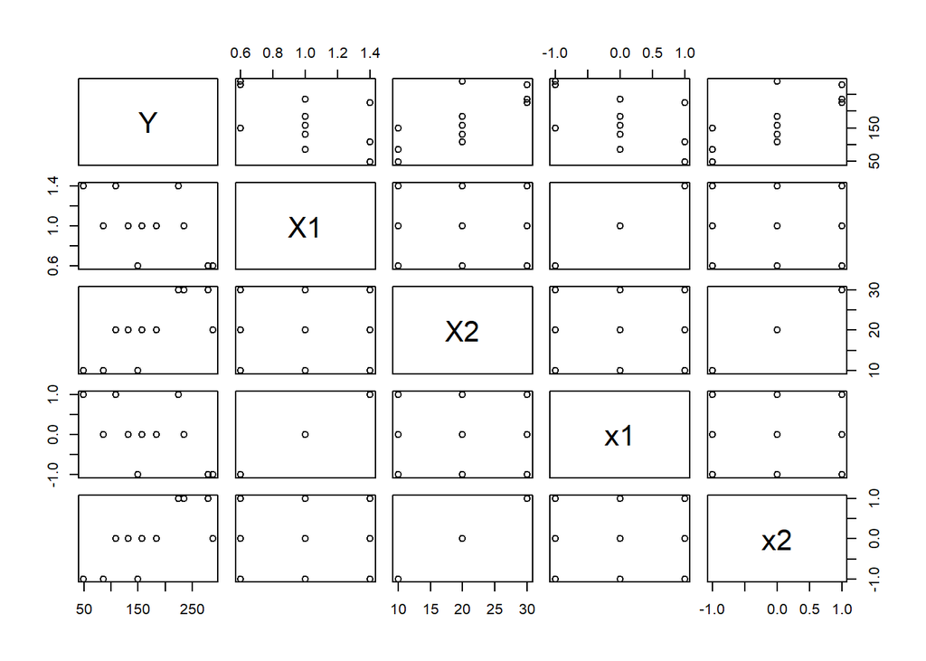

```r
# 시각화
pairs(powercell)


library(ggplot2)
```

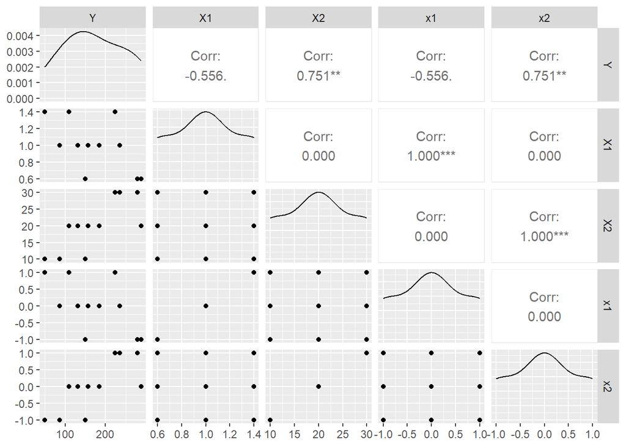

```r
library(GGally)
ggpairs(powercell)
```

## 2. 회귀 모델 비교

#### 2-1. 다항 회귀 모형(Polynomial Regression Model)

```r
lm_poly<-lm(Y~x1+x2+I(x1^2)+I(x2^2)+x1*x2, data=powercell)
summary(lm_poly)
```

```
##
## Call:
## lm(formula = Y ~ x1 + x2 + I(x1^2) + I(x2^2) + x1 * x2, data = powercell)
##
## Residuals:
##       1       2       3       4       5       6       7       8       9      10
## -21.465   9.263  12.202  41.930  -5.842 -31.842  21.158 -25.404 -20.465   7.263
##      11
##  13.202
##
## Coefficients:
##             Estimate Std. Error t value Pr(>|t|)
## (Intercept)   162.84      16.61   9.805 0.000188 ***
## x1            -55.83      13.22  -4.224 0.008292 **
## x2             75.50      13.22   5.712 0.002297 **
## I(x1^2)        27.39      20.34   1.347 0.235856
## I(x2^2)       -10.61      20.34  -0.521 0.624352
## x1:x2          11.50      16.19   0.710 0.509184
## ---
## Signif. codes:  0 '***' 0.001 '**' 0.01 '*' 0.05 '.' 0.1 ' ' 1
##
## Residual standard error: 32.37 on 5 degrees of freedom
## Multiple R-squared:  0.9135, Adjusted R-squared:  0.8271
## F-statistic: 10.57 on 5 and 5 DF,  p-value: 0.01086
```

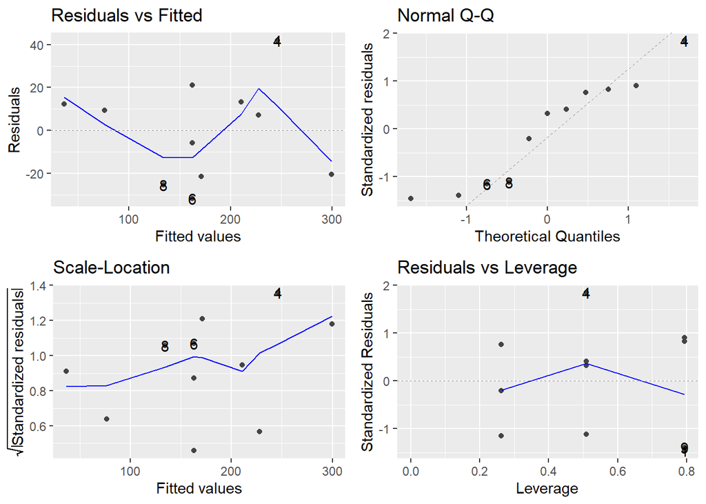

```r
library(ggplot2)
library(ggfortify)
autoplot(lm_poly)
```

- 유의미한 계수: x1, x2 - 유의하지 않은 계수: I(x1^2), I(x2^2), x1:x2 - 모델 전체는 통계적으로 유의(F = 10.57, p = 0.01086)하지만, 추가된 3개 항은 개별적으로 통계적 유의성이 없음

#### 2-2. 선형회귀 vs 다항회귀(Linear Regression vs Polynomial Regression)

```r
lm_base<-lm(Y~x1+x2, data=powercell)

anova(lm_base,lm_poly)
```

```
## Analysis of Variance Table
##
## Model 1: Y ~ x1 + x2
## Model 2: Y ~ x1 + x2 + I(x1^2) + I(x2^2) + x1 * x2
##   Res.Df    RSS Df Sum of Sq      F Pr(>F)
## 1      8 7700.3
## 2      5 5240.4  3    2459.9 0.7823 0.5527
```

- 회귀 계수 중에서 x1과 x2만 유의미
- 모델 2에서 모델 1로의 추가된 설명 변수 (다항식 항목)에 대한 F-통계량의 p-value는 0.5527으로 유의 수준인 0.05보다 크므로, 다항식 모델은 통계적으로 유의미하지 않습니다.

## 3. 회귀 계수의 신뢰구간 계산

#### 3-1. 데이터 로드 insurance

```r
insurance<-read.table("https://users.stat.ufl.edu/~rrandles/sta4210/Rclassnotes/data/textdatasets/KutnerData/Chapter%20%208%20Data%20Sets/CH08TA02.txt")
names(insurance)<-c("Y","X1","X2")
insurance$X2<-as.factor(insurance$X2)
head(insurance)
```

```
##    Y  X1 X2
## 1 17 151  0
## 2 26  92  0
## 3 21 175  0
## 4 30  31  0
## 5 22 104  0
## 6  0 277  0
```

#### 3-1. Y~X1+X2

```r
fit<-lm(Y~X1+X2, data=insurance)
summary(fit)
```

```
##
## Call:
## lm(formula = Y ~ X1 + X2, data = insurance)
##
## Residuals:
##     Min      1Q  Median      3Q     Max
## -5.6915 -1.7036 -0.4385  1.9210  6.3406
##
## Coefficients:
##              Estimate Std. Error t value Pr(>|t|)
## (Intercept) 33.874069   1.813858  18.675 9.15e-13 ***
## X1          -0.101742   0.008891 -11.443 2.07e-09 ***
## X21          8.055469   1.459106   5.521 3.74e-05 ***
## ---
## Signif. codes:  0 '***' 0.001 '**' 0.01 '*' 0.05 '.' 0.1 ' ' 1
##
## Residual standard error: 3.221 on 17 degrees of freedom
## Multiple R-squared:  0.8951, Adjusted R-squared:  0.8827
## F-statistic:  72.5 on 2 and 17 DF,  p-value: 4.765e-09
```

```r
# CI
summary(fit)$coef
```

```
##               Estimate  Std. Error    t value     Pr(>|t|)
## (Intercept) 33.8740690 1.813858297  18.675146 9.145269e-13
## X1          -0.1017421 0.008891218 -11.442990 2.074687e-09
## X21          8.0554692 1.459105700   5.520826 3.741874e-05
```

```r
summary(fit)$coef[2,1] - qt(0.975, 17)*summary(fit)$coef[2,2]
```

```
## [1] -0.1205009
```

```r
summary(fit)$coef[2,1] + qt(0.975, 17)*summary(fit)$coef[2,2]
```

```
## [1] -0.08298329
```

```r
confint(fit)
```

```
##                  2.5 %      97.5 %
## (Intercept) 30.0471625 37.70097553
## X1          -0.1205009 -0.08298329
## X21          4.9770253 11.13391314
```

- qt(0.975, 17)는 자유도가 17인 t-분포에서 상위 2.5%에 해당하는 t 값

#### 3-2. Y~X1*X2

```r
fit2<-lm(Y~X1*X2, data=insurance)
summary(fit2)
```

```
##
## Call:
## lm(formula = Y ~ X1 * X2, data = insurance)
##
## Residuals:
##     Min      1Q  Median      3Q     Max
## -5.7144 -1.7064 -0.4557  1.9311  6.3259
##
## Coefficients:
##               Estimate Std. Error t value Pr(>|t|)
## (Intercept) 33.8383695  2.4406498  13.864 2.47e-10 ***
## X1          -0.1015306  0.0130525  -7.779 7.97e-07 ***
## X21          8.1312501  3.6540517   2.225   0.0408 *
## X1:X21      -0.0004171  0.0183312  -0.023   0.9821
## ---
## Signif. codes:  0 '***' 0.001 '**' 0.01 '*' 0.05 '.' 0.1 ' ' 1
##
## Residual standard error: 3.32 on 16 degrees of freedom
## Multiple R-squared:  0.8951, Adjusted R-squared:  0.8754
## F-statistic: 45.49 on 3 and 16 DF,  p-value: 4.675e-08
```

- 모형의 설명력 (Adjusted R-squared)은 0.8754로, 모형이 데이터의 변동을 약 87.54% 정도 설명 F-statistic의 p-value는 4.675e-08으로, 모형이 통계적으로 유의미한지 여부를 검정

## 4. 선형 회귀 모델 비교

#### 4-1. 데이터 로드 soap

```r
soap<-read.table("https://users.stat.ufl.edu/~rrandles/sta4210/Rclassnotes/data/textdatasets/KutnerData/Chapter%20%208%20Data%20Sets/CH08TA05.txt")
names(soap)<-c("Y","X1","X2")
soap$X2<-as.factor(soap$X2)
head(soap)
```

```
##     Y  X1 X2
## 1 218 100  1
## 2 248 125  1
## 3 360 220  1
## 4 351 205  1
## 5 470 300  1
## 6 394 255  1
```

#### 4-2. X1과 Y 사이의 관계를 X2의 수준에 따라 시각화

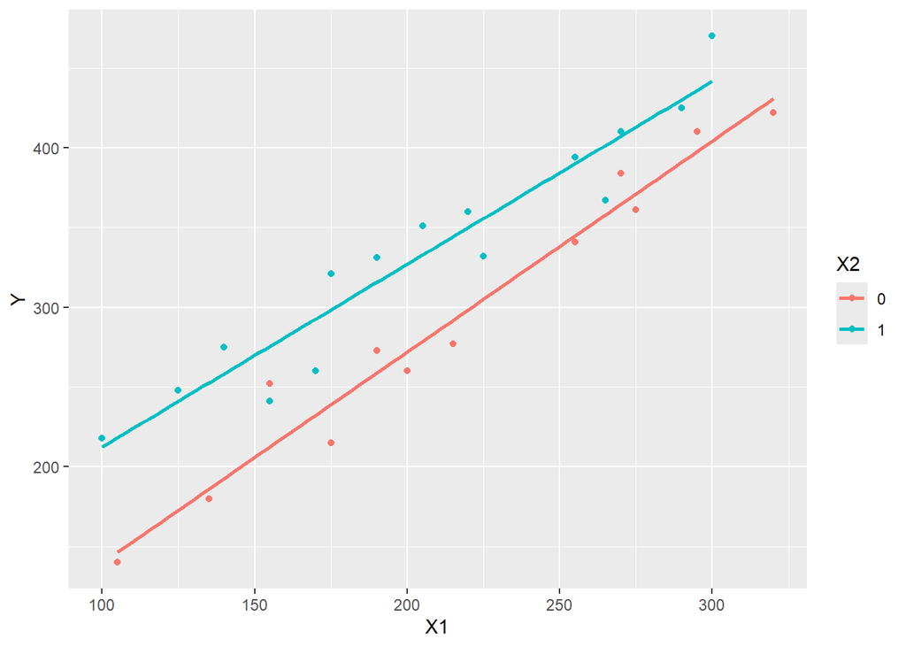

```r
g<- ggplot(soap, aes(x=X1, y=Y, colour = X2)) + geom_point()
g+geom_smooth(method=lm, se=FALSE)
```

#### 4-3. 상호작용 모형(Interaction Model)

```r
# Y~X1*X2

model_43<-lm(Y~X1*X2, data=soap)
summary(model_43)
```

```
##
## Call:
## lm(formula = Y ~ X1 * X2, data = soap)
##
## Residuals:
##    Min     1Q Median     3Q    Max
## -34.50 -11.06   2.78  14.82  39.51
##
## Coefficients:
##             Estimate Std. Error t value Pr(>|t|)
## (Intercept)  7.57446   20.86970   0.363  0.71996
## X1           1.32205    0.09262  14.273 6.45e-13 ***
## X21         90.39086   28.34573   3.189  0.00409 **
## X1:X21      -0.17666    0.12884  -1.371  0.18355
## ---
## Signif. codes:  0 '***' 0.001 '**' 0.01 '*' 0.05 '.' 0.1 ' ' 1
##
## Residual standard error: 20.75 on 23 degrees of freedom
## Multiple R-squared:  0.9447, Adjusted R-squared:  0.9375
## F-statistic: 130.9 on 3 and 23 DF,  p-value: 1.341e-14
```

#### 4-4. 단일 변수 모형 vs 상호작용 모형(Single-Variable Model vs. Interaction Model)

```r
# Y~X1

model_44<-lm(Y~X1, data=soap)
anova(model_44, model_43)
```

```
## Analysis of Variance Table
##
## Model 1: Y ~ X1
## Model 2: Y ~ X1 * X2
##   Res.Df     RSS Df Sum of Sq      F    Pr(>F)
## 1     25 29407.8
## 2     23  9904.1  2     19504 22.646 3.669e-06 ***
## ---
## Signif. codes:  0 '***' 0.001 '**' 0.01 '*' 0.05 '.' 0.1 ' ' 1
```

- 모델 44과 모델43 간의 차이가 통계적으로 유의미함 (F-statistic은 22.646이고, p-value는 3.669e-06)

#### 4-5. 다변량 모형 vs 상호작용 모형(Multivariable Model vs. Interaction Model)

```r
# Y~X1+X2

model_45<-lm(Y~X1+X2, data=soap)
anova(model_45, model_43)
```

```
## Analysis of Variance Table
##
## Model 1: Y ~ X1 + X2
## Model 2: Y ~ X1 * X2
##   Res.Df     RSS Df Sum of Sq      F Pr(>F)
## 1     24 10713.7
## 2     23  9904.1  1    809.62 1.8802 0.1835
```

- 모델 45와 모델 43 간의 차이가 통계적으로 유의미하지 않음 (F-statistic은 1.8802이고, p-value는 0.183)